# An Introduction to Supervised Learning

Ryan Miller

## Supervised Learning

- In *supervised learning* we use a set of features $\mathbf{X} = \{X_1,X_2,\ldots,X_p\}$ to model or predict an outcome variable $Y$, this can be expressed mathematically using the model:
  $$Y = f(\mathbf{X}) + \epsilon$$
- Here $f$ is a fixed but unknown function of the data, and $\epsilon$ is a random error term
  - $f$ describes the systematic relationship between the variables in $\mathbf{X}$ and $Y$

## Estimating $f$

- Because $f$ is unknown we must estimate it via $\hat{f}$, there are two motivating reasons for estimating $f$:
  - **Prediction**, if $Y$ is difficult to obtain but $\mathbf{X}$ is readily available we can use $\hat{Y} = \hat{f}(X)$ as an estimate
  - **Inference**, *how* $Y$ is affected by changes in $\mathbf{X}$ can be understood by studying $\hat{f}$
- How we estimate $f$ is *the fundamental question* in machine learning
  - Broadly speaking, there are two major approaches to this: **parametric** and **non-parametric** models

## Parametric vs. Non-parametric Models

- Non-parametric models make no explicit assumptions about the functional form of $f$ and are instead guided by an algorithm aimed at producing an estimate $\hat{f}$ that is close to $f$ (but not overfit)
- In contrast, parametric models impose a structure on the functional form of $f$, the most widely-known structure is the linear regression model:
  $$f(\mathbf{X}) = \beta_0 + \beta_1 X_{1} + \beta_2X_2 + \ldots + \beta_pX_p + \epsilon$$
- By imposing this structure, we’ve simplified the supervised learning question from estimating some arbitrary $p$-dimensional function to estimating a set of regression coefficients, $\{\beta_0, \beta_1, \ldots, \beta_p\}$
  - The tradeoff for this simplification is that the model’s structure might not be flexible enough to accurately reflect patterns in the data

## Model Training

- Making use of a parametric model requires two steps:
  - Specifying the parametric form of the model, ie: deciding $f(\mathbf{X})$ is a linear combination of $X_1, X_2, \ldots$
  - *Training* or *fitting* the model, ie: estimating the regression coefficients, or finding $\hat{\beta}_0, \hat{\beta}_1, \ldots$

## Model Training

- How a model is trained is *crucially important*
- Consider the parametric model $f(\mathbf{X}) = \beta_0 + \beta_1 X_{1} + \epsilon$
  - There are infinitely many possibilities for the coefficients $\hat{\beta}_0$ and $\hat{\beta}_1$ that satisfy this parametric form, but most of them are not good models of $f$
  - Shown below are 200 randomly chosen linear models relating $X$ and $Y$

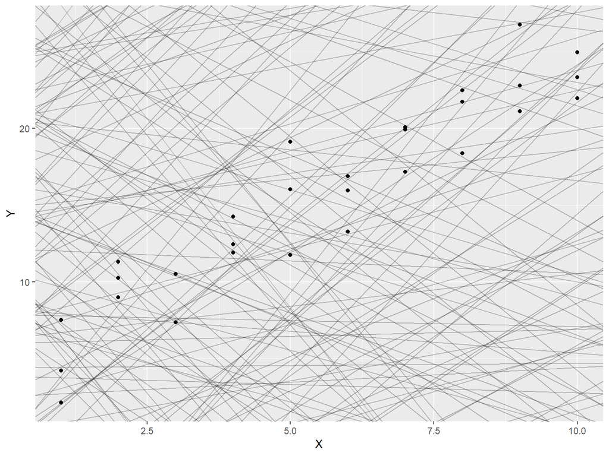

## Model Evaluation

- In order to determine whether a model is “good” we need an objective measure of it’s performance
  - A logical approach is to measure the distance between the model’s predictions ($\hat{Y}$) and the observed values of $Y$
- In this class we will focus on two measures (for numeric outcomes), Root Mean Squared Error ($RMSE$) and Mean Absolute Error ($MAE$):
  $$RMSE = \sqrt{\tfrac{1}{n}\sum_i (y_i - \hat{y}_i)^2} \qquad MAE = \tfrac{1}{n}\sum_i|y_i - \hat{y}_i|$$
- The plot below displays the 10 models (from the 200 shown on the previous slide) with the lowest $RMSE$:

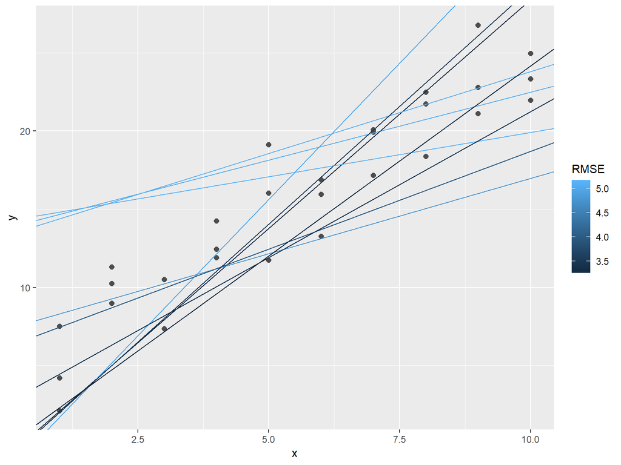

## Model Training - Revisited

- Randomly choosing values to use as estimates of $\beta_0$ and $\beta_1$ is an extremely inefficient method for finding a good model
- In this class we’ll consider two types of estimates for linear regression models
  - Ordinary Least Squares (OLS) estimates, which are found minimizing $RMSE$
  - Least absolute shrinkage and selection operator (LASSO) estimates, which are found by minimizing $RMSE$ subject to a constraint on the total size of the coefficients: $\sum_{j=1}^p |\beta_j| \leq s$, an approach known as **regularization**

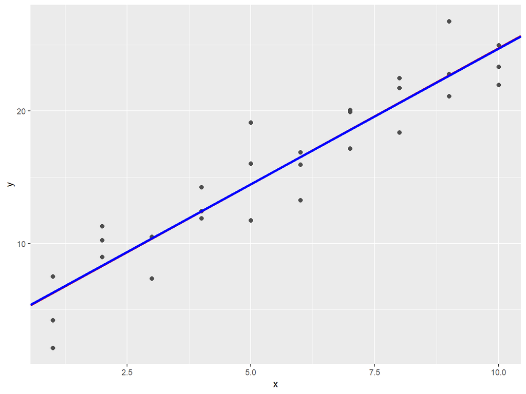